# Biostat 203B Homework 5

Due Mar 22 @ 11:59PM

Author

Bowen Zhang UID: 506126821

## Predicting ICU duration

Using the ICU cohort `mimiciv_icu_cohort.rds` you built in Homework 4, develop **at least three machine learning approaches** (logistic regression with enet regularization, random forest, boosting, SVM, MLP, etc) plus a **model stacking approach** for predicting whether a patient’s ICU stay will be longer than 2 days. You should use the `los_long` variable as the outcome. You algorithms can use **patient demographic information** (gender, age at ICU `intime`, marital status, race), **ICU admission information** (first care unit), **the last lab measurements before the ICU stay**, and **first vital measurements during ICU stay** as features. You are welcome to use any feature engineering techniques you think are appropriate; but make sure to not use features that are not available at an ICU stay’s `intime`. For instance, `last_careunit` cannot be used in your algorithms.

1. Data preprocessing and feature engineering.
2. Partition data into 50% training set and 50% test set. Stratify partitioning according to `los_long`. For grading purpose, sort the data by `subject_id`, `hadm_id`, and `stay_id` and use the seed `203` for the initial data split. Below is the sample code.
3. Train and tune the models using the training set.
4. Compare model classification performance on the test set. Report both the area under ROC curve and accuracy for each machine learning algorithm and the model stacking. Interpret the results. What are the most important features in predicting long ICU stays? How do the models compare in terms of performance and interpretability?

```r
# load libraries
library(tidyverse)
library(tidymodels)
library(gtsummary)
library(ggplot2)
library(xgboost)
library(kernlab)
library(keras)
library(stacks)
```

```r
# load data
mimiciv_icu_cohort <- readRDS("../hw4/mimiciv_shiny/mimic_icu_cohort.rds") |>
  select(subject_id, hadm_id, stay_id, first_careunit, marital_status,
         race, gender, age_intime, Chloride, Glucose, Sodium, Creatinine,
         Bicarbonate, Potassium, WBC, Hematocrit, NBPs, RR, HR, TempF,
         NBPd, los_long) |>
  mutate(gender = as_factor(gender),
         # If marital_status is NA, set it as unknown category
         marital_status = fct_explicit_na(marital_status, na_level = "UNKNOWN"),
         gender = as_factor(gender),
         los_long = as_factor(los_long))
# Get the summary of the dataset
tbl_summary(mimiciv_icu_cohort)
```

| **Characteristic** | **N = 73,181**<sup>1</sup> |
| --- | --- |
| subject_id | 14,998,941 (12,491,257, 17,513,267) |
| hadm_id | 24,969,636 (22,483,349, 27,471,796) |
| stay_id | 34,993,892 (32,489,353, 37,488,401) |
| first_careunit |  |
| Cardiac Vascular Intensive Care Unit (CVICU) | 11,582 (16%) |
| Medical Intensive Care Unit (MICU) | 15,898 (22%) |
| Medical/Surgical Intensive Care Unit (MICU/SICU) | 12,733 (17%) |
| Surgical Intensive Care Unit (SICU) | 11,161 (15%) |
| Other | 21,807 (30%) |
| marital_status |  |
| DIVORCED | 5,404 (7.4%) |
| MARRIED | 32,768 (45%) |
| SINGLE | 20,858 (29%) |
| WIDOWED | 9,038 (12%) |
| UNKNOWN | 5,113 (7.0%) |
| race |  |
| Other | 10,756 (15%) |
| ASIAN | 2,155 (2.9%) |
| BLACK | 7,960 (11%) |
| HISPANIC | 2,741 (3.7%) |
| WHITE | 49,569 (68%) |
| gender |  |
| F | 32,363 (44%) |
| M | 40,818 (56%) |
| age_intime | 66 (54, 77) |
| Chloride | 102 (98, 105) |
| Unknown | 8,883 |
| Glucose | 120 (99, 156) |
| Unknown | 9,099 |
| Sodium | 139.0 (136.0, 141.0) |
| Unknown | 8,872 |
| Creatinine | 1.00 (0.80, 1.50) |
| Unknown | 5,770 |
| Bicarbonate | 25.0 (22.0, 27.0) |
| Unknown | 9,050 |
| Potassium | 4.20 (3.80, 4.60) |
| Unknown | 8,901 |
| WBC | 9.3 (6.8, 13.2) |
| Unknown | 5,094 |
| Hematocrit | 35 (30, 40) |
| Unknown | 5,017 |
| NBPs | 121 (106, 139) |
| Unknown | 979 |
| RR | 98.20 (97.60, 98.70) |
| Unknown | 1,362 |
| HR | 86 (74, 101) |
| Unknown | 18 |
| TempF | 18.0 (15.0, 22.0) |
| Unknown | 98 |
| NBPd | 67 (57, 79) |
| Unknown | 983 |
| los_long |  |
| FALSE | 38,050 (52%) |
| TRUE | 35,131 (48%) |

<sup>1</sup> Median (IQR); n (%)

```r
set.seed(203)

# sort
mimiciv_icu_cohort <- mimiciv_icu_cohort |>
  arrange(subject_id, hadm_id, stay_id)

data_split <- initial_split(
  mimiciv_icu_cohort,
  # stratify by los_long
  strata = "los_long",
  prop = 0.5
  )

all_train_set <- training(data_split) |>
  select(-c(subject_id, hadm_id, stay_id))

test_set <- testing(data_split) |>
  select(-c(subject_id, hadm_id, stay_id))
```

```r
# Recipe
gb_recipe <-
  recipe(
    los_long ~ .,
    data = all_train_set
  ) |>
  # median imputation for continuous variables
  step_impute_median(c(Chloride, Glucose, Sodium, Creatinine, Bicarbonate,
                       Potassium, WBC, Hematocrit, NBPs, RR, HR, TempF,
                       NBPd)) |>
  # create traditional dummy variables
  step_dummy(all_nominal_predictors()) |>
  # zero-variance filter
  step_zv(all_numeric_predictors()) |>
  # center and scale numeric data
  step_normalize(all_numeric_predictors()) |>
  print()
```

```
── Recipe ──────────────────────────────────────────────────────────────────────
```

```
── Inputs
```

```
Number of variables by role
```

```
outcome:    1
predictor: 18
```

```
── Operations
```

```
• Median imputation for: c(Chloride, Glucose, Sodium, Creatinine, Bicarbonate,
  Potassium, WBC, Hematocrit, NBPs, RR, HR, TempF, NBPd)
```

```
• Dummy variables from: all_nominal_predictors()
```

```
• Zero variance filter on: all_numeric_predictors()
```

```
• Centering and scaling for: all_numeric_predictors()
```

### Model 1 – XGBoost

```r
# Model 1 -- XGBoost

set.seed(203)
gb_mod <-
  boost_tree(
    mode = "classification",
    trees = 600,
    mtry = 9,
    tree_depth = tune(),
    learn_rate = tune()
  ) |>
  set_engine("xgboost")
gb_mod
```

```
Boosted Tree Model Specification (classification)

Main Arguments:
  mtry = 9
  trees = 600
  tree_depth = tune()
  learn_rate = tune()

Computational engine: xgboost
```

```r
gb_wf <- workflow() |>
  add_recipe(gb_recipe) |>
  add_model(gb_mod)

# Tune the model
param_grid <- grid_regular(
  tree_depth(range = c(1L, 5L)),
  learn_rate(range = c(-4, 1), trans = log10_trans()),
  levels = c(3, 7)
  )
param_grid
```

```
# A tibble: 21 × 2
   tree_depth learn_rate
        <int>      <dbl>
 1          1   0.0001
 2          3   0.0001
 3          5   0.0001
 4          1   0.000681
 5          3   0.000681
 6          5   0.000681
 7          1   0.00464
 8          3   0.00464
 9          5   0.00464
10          1   0.0316
# ℹ 11 more rows
```

```
# A tibble: 42 × 8
   tree_depth learn_rate .metric  .estimator  mean     n std_err
        <int>      <dbl> <chr>    <chr>      <dbl> <int>   <dbl>
 1          1   0.0001   accuracy binary     0.544     5 0.00363
 2          1   0.0001   roc_auc  binary     0.576     5 0.00362
 3          3   0.0001   accuracy binary     0.564     5 0.00370
 4          3   0.0001   roc_auc  binary     0.595     5 0.00332
 5          5   0.0001   accuracy binary     0.577     5 0.00364
 6          5   0.0001   roc_auc  binary     0.611     5 0.00326
 7          1   0.000681 accuracy binary     0.548     5 0.00351
 8          1   0.000681 roc_auc  binary     0.579     5 0.00327
 9          3   0.000681 accuracy binary     0.569     5 0.00342
10          3   0.000681 roc_auc  binary     0.600     5 0.00362
   .config
   <chr>
 1 Preprocessor1_Model01
 2 Preprocessor1_Model01
 3 Preprocessor1_Model02
 4 Preprocessor1_Model02
 5 Preprocessor1_Model03
 6 Preprocessor1_Model03
 7 Preprocessor1_Model04
 8 Preprocessor1_Model04
 9 Preprocessor1_Model05
10 Preprocessor1_Model05
# ℹ 32 more rows
```

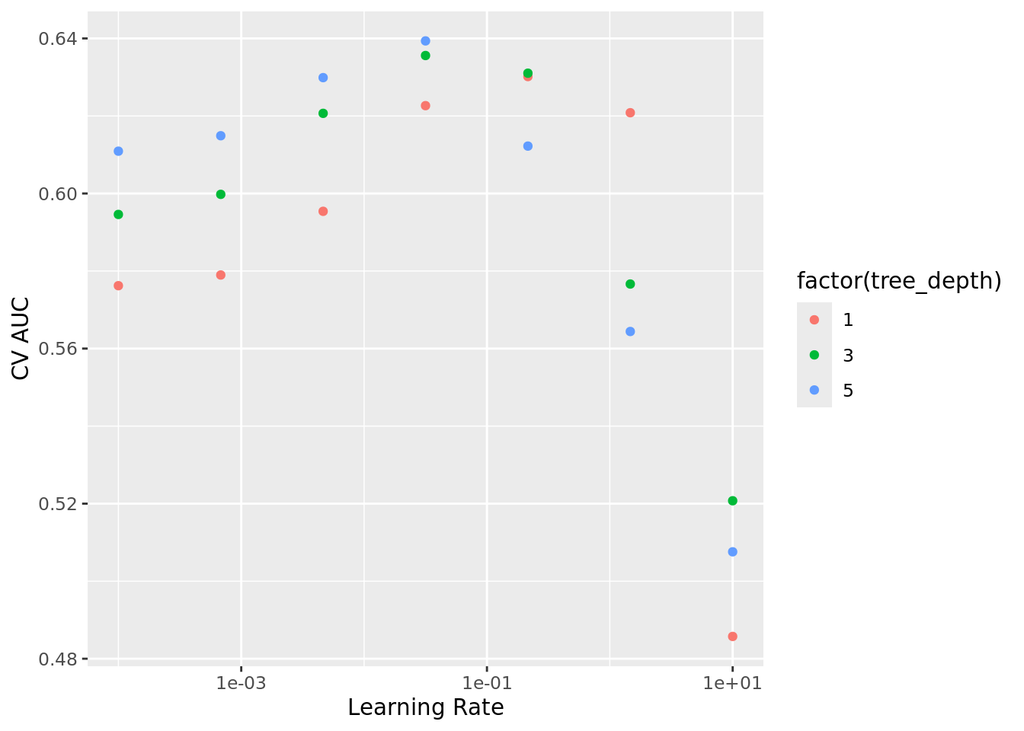

```r
# Train the model
set.seed(203)

folds <- vfold_cv(all_train_set, v = 5)

gb_fit <- gb_wf |>
  tune_grid(
    resamples = folds,
    grid = param_grid,
    metrics = metric_set(roc_auc, accuracy)
    )

gb_fit |>
  collect_metrics() |>
  print(width = Inf) |>
  filter(.metric == "roc_auc") |>
  ggplot(mapping = aes(x = learn_rate, y = mean, color = factor(tree_depth))) +
  geom_point() +
  labs(x = "Learning Rate", y = "CV AUC") +
  scale_x_log10()
```

```r
gb_fit |>
  show_best("roc_auc")
```

```
# A tibble: 5 × 8
  tree_depth learn_rate .metric .estimator  mean     n std_err .config
       <int>      <dbl> <chr>   <chr>      <dbl> <int>   <dbl> <chr>
1          5    0.0316  roc_auc binary     0.639     5 0.00313 Preprocessor1_Mo…
2          3    0.0316  roc_auc binary     0.636     5 0.00291 Preprocessor1_Mo…
3          3    0.215   roc_auc binary     0.631     5 0.00349 Preprocessor1_Mo…
4          1    0.215   roc_auc binary     0.630     5 0.00266 Preprocessor1_Mo…
5          5    0.00464 roc_auc binary     0.630     5 0.00333 Preprocessor1_Mo…
```

```r
best_gb <- gb_fit |>
  select_best("roc_auc")
best_gb
```

```
# A tibble: 1 × 3
  tree_depth learn_rate .config
       <int>      <dbl> <chr>
1          5     0.0316 Preprocessor1_Model12
```

According to the result, when `tree_depth = 5`, `learn_rate = 0.0316`, the model has the best performance via 5-fold CV. It has mean AUC of 0.639. In order to shorten the training time, and to avoid overfitting, I set the `mtry = 9` (randomly choose 9 variables from predictors).

### Model 2 – SVM

```r
# Model 2 -- SVM

svm_mod <-
  svm_rbf(
    mode = "classification",
    cost = tune(),
    rbf_sigma = tune()
  ) |>
  set_engine("kernlab")
svm_mod
```

```
Radial Basis Function Support Vector Machine Model Specification (classification)

Main Arguments:
  cost = tune()
  rbf_sigma = tune()

Computational engine: kernlab
```

```r
svm_wf <- workflow() |>
  add_recipe(gb_recipe) |>
  add_model(svm_mod)

# Tune the model
param_grid <- grid_regular(
  cost(range = c(-3, 2)),
  rbf_sigma(range = c(-3, 0)),
  levels = c(3, 3)
  )
param_grid
```

```
# A tibble: 9 × 2
   cost rbf_sigma
  <dbl>     <dbl>
1 0.125    0.001
2 0.707    0.001
3 4        0.001
4 0.125    0.0316
5 0.707    0.0316
6 4        0.0316
7 0.125    1
8 0.707    1
9 4        1
```

```
# A tibble: 18 × 8
    cost rbf_sigma .metric  .estimator  mean     n   std_err
   <dbl>     <dbl> <chr>    <chr>      <dbl> <int>     <dbl>
 1 0.125    0.001  accuracy binary     0.554     2 0.00139
 2 0.125    0.001  roc_auc  binary     0.597     2 0.00128
 3 0.707    0.001  accuracy binary     0.571     2 0.00159
 4 0.707    0.001  roc_auc  binary     0.602     2 0.000914
 5 4        0.001  accuracy binary     0.576     2 0.00109
 6 4        0.001  roc_auc  binary     0.608     2 0.000501
 7 0.125    0.0316 accuracy binary     0.584     2 0.00139
 8 0.125    0.0316 roc_auc  binary     0.618     2 0.00113
 9 0.707    0.0316 accuracy binary     0.587     2 0.000219
10 0.707    0.0316 roc_auc  binary     0.620     2 0.0000703
11 4        0.0316 accuracy binary     0.580     2 0.000902
12 4        0.0316 roc_auc  binary     0.611     2 0.00131
```

[output cut: 26 more lines]

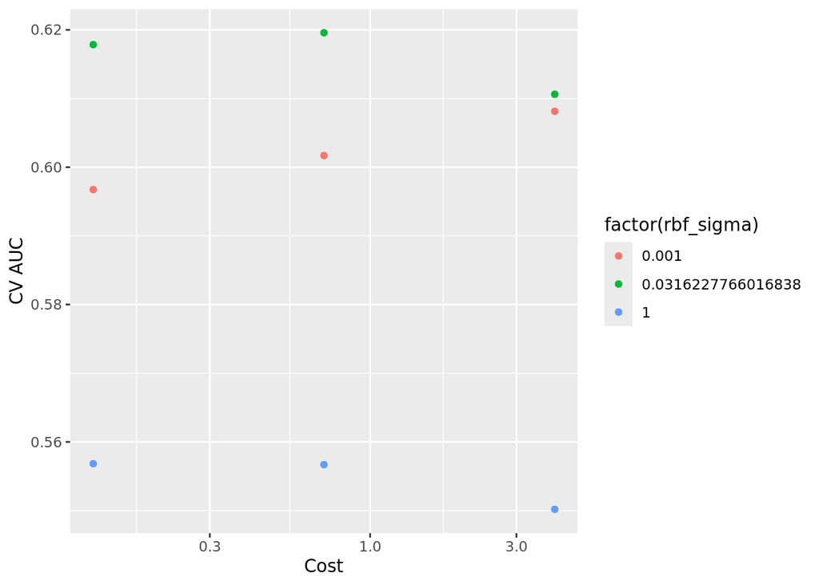

```r
set.seed(203)

folds <- vfold_cv(all_train_set, v = 2)

svm_fit <- svm_wf |>
  tune_grid(
    resamples = folds,
    grid = param_grid,
    metrics = metric_set(roc_auc, accuracy)
    )

svm_fit |>
  collect_metrics() |>
  print(width = Inf) |>
  filter(.metric == "roc_auc") |>
  ggplot(mapping = aes(x = cost, y = mean, color = factor(rbf_sigma))) +
  geom_point() +
  labs(x = "Cost", y = "CV AUC") +
  scale_x_log10()
```

```r
svm_fit |>
  show_best("roc_auc")
```

```
# A tibble: 5 × 8
   cost rbf_sigma .metric .estimator  mean     n   std_err .config
  <dbl>     <dbl> <chr>   <chr>      <dbl> <int>     <dbl> <chr>
1 0.707    0.0316 roc_auc binary     0.620     2 0.0000703 Preprocessor1_Model5
2 0.125    0.0316 roc_auc binary     0.618     2 0.00113   Preprocessor1_Model4
3 4        0.0316 roc_auc binary     0.611     2 0.00131   Preprocessor1_Model6
4 4        0.001  roc_auc binary     0.608     2 0.000501  Preprocessor1_Model3
5 0.707    0.001  roc_auc binary     0.602     2 0.000914  Preprocessor1_Model2
```

```r
best_svm <- svm_fit |>
  select_best("roc_auc")
best_svm
```

```
# A tibble: 1 × 3
   cost rbf_sigma .config
  <dbl>     <dbl> <chr>
1 0.707    0.0316 Preprocessor1_Model5
```

According to the result, when `cost = 0.707`, `rbf_sigma = 0.0316`, the model has the best performance via 2-fold CV. It has mean AUC of 0.620. Since the training time of SVM is very long, I only use 2-fold CV to tune the model. Using 2-fold CV and 3 by 3 grid search, the training process still takes more than 15 mins.

### Model 3 – Logistic Regression

```r
# Model 3 -- Logistic Regression

logit_mod <-
  logistic_reg(
    penalty = tune(),
    mixture = tune()
  ) |>
  set_engine("glmnet", standardize = FALSE) |>
  print()
```

```
Logistic Regression Model Specification (classification)

Main Arguments:
  penalty = tune()
  mixture = tune()

Engine-Specific Arguments:
  standardize = FALSE

Computational engine: glmnet
```

```r
logit_wf <- workflow() |>
  add_recipe(gb_recipe) |>
  add_model(logit_mod)

# Tune the model
param_grid <- grid_regular(
  penalty(range = c(-5, 2)),
  mixture(),
  levels = c(50, 5)
  ) |>
  print()
```

```
# A tibble: 250 × 2
     penalty mixture
       <dbl>   <dbl>
 1 0.00001         0
 2 0.0000139       0
 3 0.0000193       0
 4 0.0000268       0
 5 0.0000373       0
 6 0.0000518       0
 7 0.0000720       0
 8 0.0001          0
 9 0.000139        0
10 0.000193        0
# ℹ 240 more rows
```

```
# A tibble: 500 × 8
     penalty mixture .metric  .estimator  mean     n std_err
       <dbl>   <dbl> <chr>    <chr>      <dbl> <int>   <dbl>
 1 0.00001         0 accuracy binary     0.577     5 0.00139
 2 0.00001         0 roc_auc  binary     0.603     5 0.00263
 3 0.0000139       0 accuracy binary     0.577     5 0.00139
 4 0.0000139       0 roc_auc  binary     0.603     5 0.00263
 5 0.0000193       0 accuracy binary     0.577     5 0.00139
 6 0.0000193       0 roc_auc  binary     0.603     5 0.00263
 7 0.0000268       0 accuracy binary     0.577     5 0.00139
 8 0.0000268       0 roc_auc  binary     0.603     5 0.00263
 9 0.0000373       0 accuracy binary     0.577     5 0.00139
10 0.0000373       0 roc_auc  binary     0.603     5 0.00263
   .config
   <chr>
 1 Preprocessor1_Model001
 2 Preprocessor1_Model001
 3 Preprocessor1_Model002
 4 Preprocessor1_Model002
 5 Preprocessor1_Model003
 6 Preprocessor1_Model003
 7 Preprocessor1_Model004
 8 Preprocessor1_Model004
 9 Preprocessor1_Model005
10 Preprocessor1_Model005
# ℹ 490 more rows
```

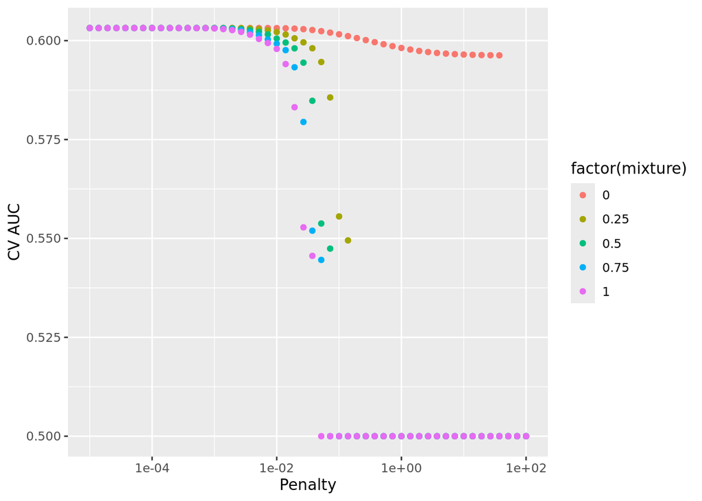

```r
set.seed(203)
folds <- vfold_cv(all_train_set, v = 5)

logit_fit <- logit_wf |>
  tune_grid(
    resamples = folds,
    grid = param_grid,
    metrics = metric_set(roc_auc, accuracy)
    )

logit_fit |>
  # aggregate metrics from K folds
  collect_metrics() |>
  print(width = Inf) |>
  filter(.metric == "roc_auc") |>
  ggplot(mapping = aes(x = penalty, y = mean, color = factor(mixture))) +
  geom_point() +
  labs(x = "Penalty", y = "CV AUC") +
  scale_x_log10()
```

```r
logit_fit |>
  show_best("roc_auc")
```

```
# A tibble: 5 × 8
    penalty mixture .metric .estimator  mean     n std_err .config
      <dbl>   <dbl> <chr>   <chr>      <dbl> <int>   <dbl> <chr>
1 0.00001      0.25 roc_auc binary     0.603     5 0.00265 Preprocessor1_Model0…
2 0.0000139    0.25 roc_auc binary     0.603     5 0.00265 Preprocessor1_Model0…
3 0.0000193    0.25 roc_auc binary     0.603     5 0.00265 Preprocessor1_Model0…
4 0.0000268    0.25 roc_auc binary     0.603     5 0.00265 Preprocessor1_Model0…
5 0.0000373    0.25 roc_auc binary     0.603     5 0.00265 Preprocessor1_Model0…
```

```r
best_logit <- logit_fit |>
  select_best("roc_auc")
best_logit
```

```
# A tibble: 1 × 3
  penalty mixture .config
    <dbl>   <dbl> <chr>
1 0.00001    0.25 Preprocessor1_Model051
```

According to the result, when `penalty = 1e-05`, `mixture = 0.25`, the model has the best performance via 5-fold CV. It has mean AUC of 0.603. There are not obvious “U curve” in the plot of grid search, and many combinations of penalty and mixture have similar performance. I simply choose the best combination on the top of the list.

### Stacking Model

```r
# Stacking models

set.seed(203)
folds <- vfold_cv(all_train_set, v = 2)

# Logistic
logit_stack_mod <-
  logistic_reg(
    penalty = tune(),
    mixture = tune()
  ) |>
  set_engine("glmnet", standardize = TRUE)

logit_stack_wf <- workflow() |>
  add_recipe(gb_recipe) |>
  add_model(logit_stack_mod)

logit_stack_grid <- grid_regular(
  penalty(range = c(-5, 2)),
  mixture(),
  levels = c(5, 5)
  )

logit_res <-
  tune_grid(
    object = logit_stack_wf,
    resamples = folds,
    grid = logit_stack_grid,
    control = control_stack_grid()
  )

# SVM
svm_stack_mod <-
  svm_rbf(
    mode = "classification",
    cost = tune(),
    rbf_sigma = 0.03162278,
  ) |>
  set_engine("kernlab")

svm_stack_wf <- workflow() |>
  add_recipe(gb_recipe) |>
  add_model(svm_stack_mod)

svm_stack_grid <- grid_regular(
  cost(range = c(-3, 2)),
  levels = c(3)
  )

svm_res <- svm_stack_wf |>
  tune_grid(
    object = svm_stack_wf,
    resamples = folds,
    grid = svm_stack_grid,
    control = control_stack_grid()
    )
# XGBoost
gb_stack_mod <-
  boost_tree(
    mode = "classification",
    trees = 500,
    mtry = 9,
    tree_depth = tune(),
    learn_rate = tune()
  ) |>
  set_engine("xgboost")

gb_stack_wf <- workflow() |>
  add_recipe(gb_recipe) |>
  add_model(gb_stack_mod)

gb_stack_grid <- grid_regular(
  tree_depth(range = c(1L, 3L)),
  learn_rate(range = c(-4, 1), trans = log10_trans()),
  levels = c(2, 5)
  )

gb_res <- gb_stack_wf |>
  tune_grid(
    object = gb_stack_wf,
    resamples = folds,
    grid = gb_stack_grid,
    control = control_stack_grid()
    )
# Model stacking
mimic_model_st <-
  stacks() |>
  # add candidate members
  add_candidates(logit_res) |>
  add_candidates(gb_res) |>
  add_candidates(svm_res) |>
  # determine how to combine their predictions
  blend_predictions(
    penalty = 10^(-3:1),
    metrics = c("roc_auc"),
    times = 3
    ) |>
  # fit the candidates with nonzero stacking coefficients
  fit_members()
mimic_model_st
```

```
── A stacked ensemble model ─────────────────────────────────────


Out of 26 possible candidate members, the ensemble retained 5.

Penalty: 0.01.

Mixture: 1.


The 5 highest weighted member classes are:
```

```
# A tibble: 5 × 3
  member                 type       weight
  <chr>                  <chr>       <dbl>
1 .pred_TRUE_gb_res_1_06 boost_tree  2.45
2 .pred_TRUE_svm_res_1_2 svm_rbf     0.877
3 .pred_TRUE_svm_res_1_3 svm_rbf     0.480
4 .pred_TRUE_gb_res_1_07 boost_tree  0.374
5 .pred_TRUE_gb_res_1_08 boost_tree  0.237
```

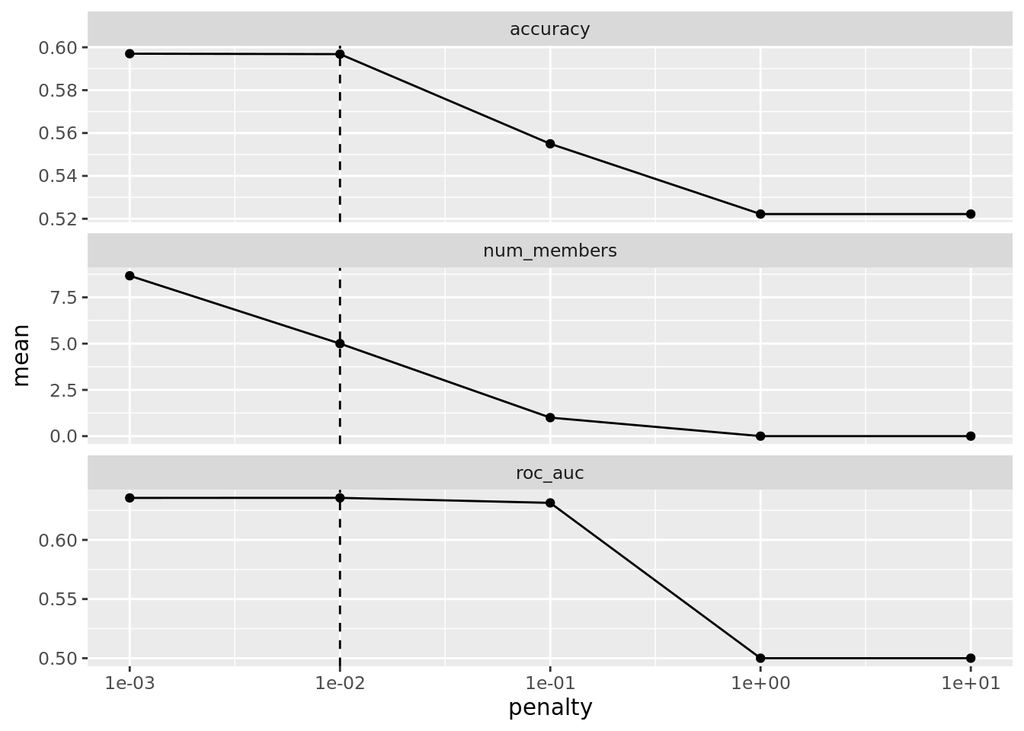

```r
autoplot(mimic_model_st)
```

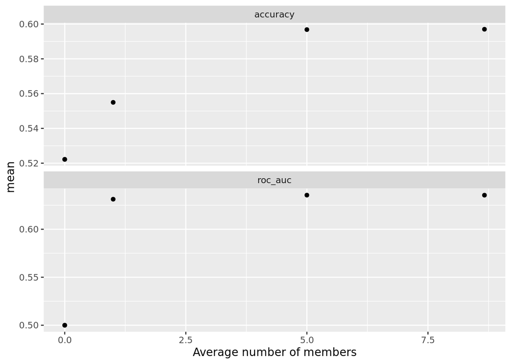

```r
autoplot(mimic_model_st, type = "members")
```

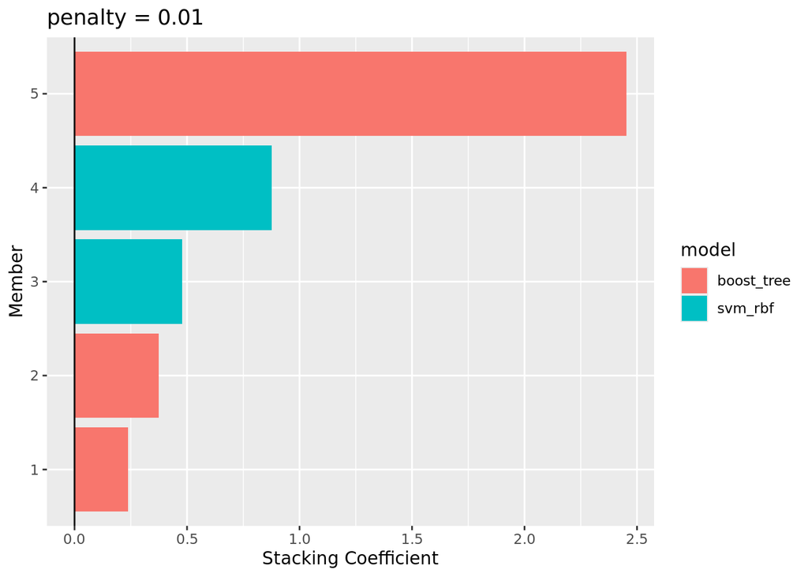

```r
autoplot(mimic_model_st, type = "weights")
```

The stacking model combines 3 XGBoost models and 2 SVM models. The Boosting model has the highest weight, followed by the SVM model. The logistic model is not included in the final stacking model.

### Model Performance on Test Set

```r
# Final workflow for XGBoost
set.seed(203)
final_wf_gb <- gb_wf |>
  finalize_workflow(best_gb)
final_wf_gb
```

```
══ Workflow ════════════════════════════════════════════════════════════════════
Preprocessor: Recipe
Model: boost_tree()

── Preprocessor ────────────────────────────────────────────────────────────────
4 Recipe Steps

• step_impute_median()
• step_dummy()
• step_zv()
• step_normalize()

── Model ───────────────────────────────────────────────────────────────────────
Boosted Tree Model Specification (classification)

Main Arguments:
  mtry = 9
  trees = 600
  tree_depth = 5
  learn_rate = 0.0316227766016838

Computational engine: xgboost
```

```r
final_fit_gb <-
  final_wf_gb |>
  last_fit(data_split)

# Test metrics
final_fit_gb |>
  collect_metrics()
```

```
# A tibble: 2 × 4
  .metric  .estimator .estimate .config
  <chr>    <chr>          <dbl> <chr>
1 accuracy binary         0.597 Preprocessor1_Model1
2 roc_auc  binary         0.637 Preprocessor1_Model1
```

The AUC and accuracy of the XGBoost model on the test set are 0.637 and 0.597, respectively.

```r
# Final workflow for SVM
final_wf_svm <- svm_wf |>
  finalize_workflow(best_svm)
final_wf_svm
```

```
══ Workflow ════════════════════════════════════════════════════════════════════
Preprocessor: Recipe
Model: svm_rbf()

── Preprocessor ────────────────────────────────────────────────────────────────
4 Recipe Steps

• step_impute_median()
• step_dummy()
• step_zv()
• step_normalize()

── Model ───────────────────────────────────────────────────────────────────────
Radial Basis Function Support Vector Machine Model Specification (classification)

Main Arguments:
  cost = 0.707106781186548
  rbf_sigma = 0.0316227766016838

Computational engine: kernlab
```

```r
final_fit_svm <-
  final_wf_svm |>
  last_fit(data_split)

final_fit_svm |>
  collect_metrics()
```

```
# A tibble: 2 × 4
  .metric  .estimator .estimate .config
  <chr>    <chr>          <dbl> <chr>
1 accuracy binary         0.584 Preprocessor1_Model1
2 roc_auc  binary         0.618 Preprocessor1_Model1
```

The AUC and accuracy of the SVM model on the test set are 0.618 and 0.584, respectively.

```r
# Final workflow for Logistic Regression
final_wf_logit <- logit_wf |>
  finalize_workflow(best_logit)
final_wf_logit
```

```
══ Workflow ════════════════════════════════════════════════════════════════════
Preprocessor: Recipe
Model: logistic_reg()

── Preprocessor ────────────────────────────────────────────────────────────────
4 Recipe Steps

• step_impute_median()
• step_dummy()
• step_zv()
• step_normalize()

── Model ───────────────────────────────────────────────────────────────────────
Logistic Regression Model Specification (classification)

Main Arguments:
  penalty = 1e-05
  mixture = 0.25

Engine-Specific Arguments:
  standardize = FALSE

Computational engine: glmnet
```

```r
final_fit_logit <-
  final_wf_logit |>
  last_fit(data_split)

final_fit_logit |>
  collect_metrics()
```

```
# A tibble: 2 × 4
  .metric  .estimator .estimate .config
  <chr>    <chr>          <dbl> <chr>
1 accuracy binary         0.573 Preprocessor1_Model1
2 roc_auc  binary         0.595 Preprocessor1_Model1
```

The AUC and accuracy of the Logistic model on the test set are 0.595 and 0.573, respectively.

```r
# Final workflow for Stacking

mimic_pred <- test_set %>%
  bind_cols(predict(mimic_model_st, ., type = "prob")) |>
  mutate(.pred_class = if_else(.pred_TRUE > .pred_FALSE, "TRUE", "FALSE"),
         .pred_class = as.factor(.pred_class))



yardstick::roc_auc(
  mimic_pred,
  truth = los_long,
  contains(".pred_FALSE")
  )
```

```
# A tibble: 1 × 3
  .metric .estimator .estimate
  <chr>   <chr>          <dbl>
1 roc_auc binary         0.636
```

```r
yardstick::accuracy(
  mimic_pred,
  truth = los_long,
  estimate = .pred_class
  )
```

```
# A tibble: 1 × 3
  .metric  .estimator .estimate
  <chr>    <chr>          <dbl>
1 accuracy binary         0.596
```

The AUC and accuracy of the stacking model on the test set are 0.636 and 0.596, respectively.

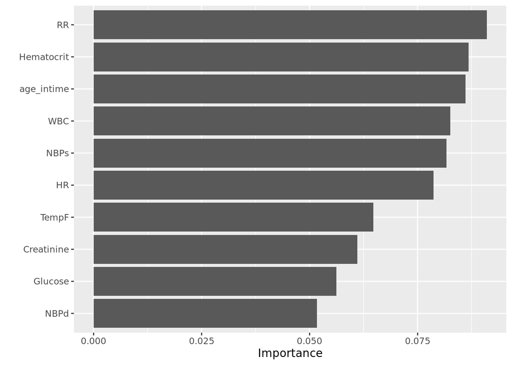

```r
# Feature importance for XGBoost
feature_importance_gb <- final_fit_gb %>%
  extract_fit_parsnip() %>%
  pluck("fit") %>%
  vip::vip()

print(feature_importance_gb)
```

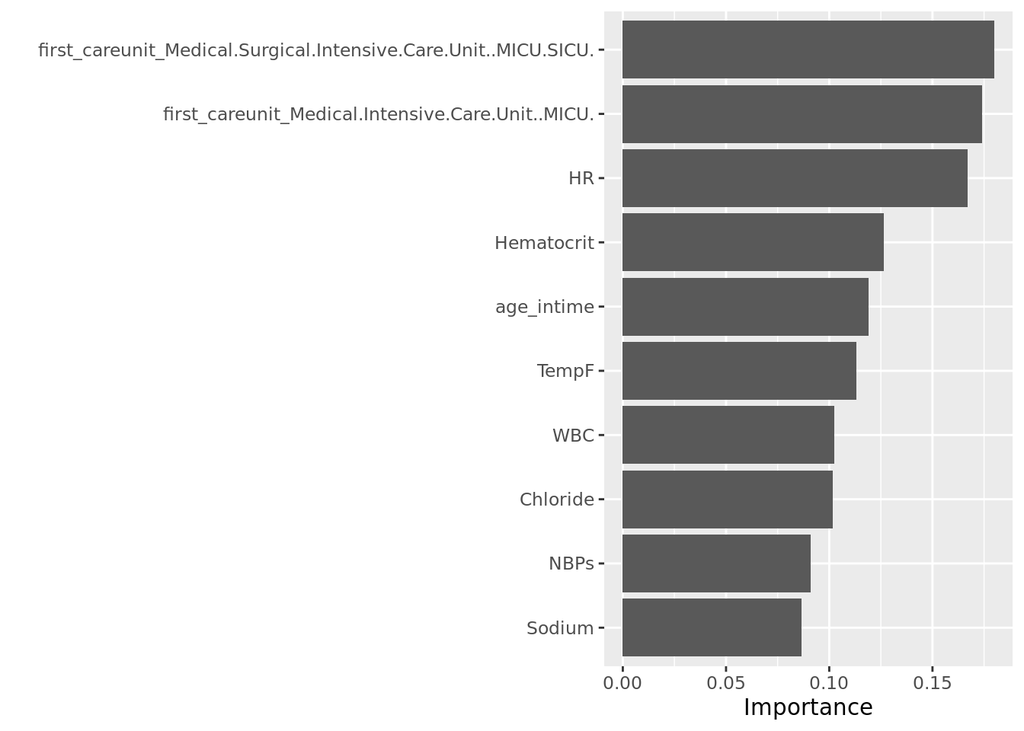

```r
# Feature importance for Logistic Regression
feature_importance_logit <- final_fit_logit |>
  extract_fit_parsnip() |>
  pluck("fit") |>
  vip::vip()

print(feature_importance_logit)
```

### Conclusion

According to the AUC and accuracy, the XGBoost model has the best performance on the test set. The stacking model has similar performance to the XGBoost model. Logistic model is the worst model among those four models, (but it is much faster than others). The stacking model does not beat the XGBoost model, probably because I did not tune the stacking model too much due to the time limit. The SVM is not suitable for dataset with so many observations such as this one, because the training time is too long.